# Computer Practical ‘R0 estimation’

# Practical Estimation of R₀ from various sources of information

This practical guide demonstrates three methods to estimate the basic reproduction number (R₀) from field data:

1. From the exponential growth phase of an epidemic
2. From the final size of an epidemic
3. From the endemic steady state

**Before starting:** Download the zip-file “EstimationROFieldData.zip” from the course website and unzip it at a convenient location. Ensure the CSV files (SARS.csv, RacingHorses.csv, Salmonella.csv) are in your working directory.

```r
# Set your working directory to the location of the CSV files
data_path <- "../data/"
```

# 1. Estimation of R₀ from the exponential growth phase

## Theory

When an epidemic is in its initial phase, both prevalence and incidence increase exponentially. During this exponential growth phase, the proportion of susceptibles in the population remains approximately constant ($X \approx N \Leftrightarrow x \approx 1$), allowing us to estimate the exponential growth rate $r$ from incidence data and then use it to estimate R₀.

The relationship between $r$ and R₀ requires the **mean generation time** $T_g$ (the mean time at which an infected person infects new cases, measured from their own infection time). In the basic SIR model, $T_g = 1/\gamma$ where $\gamma$ is the recovery rate.

From the SIR model equations:

$$r = \beta - \gamma \Rightarrow \beta =
\gamma + r$$

Thus

$$R_0 = 1 + \dfrac{r}{\gamma} = 1 + r
T_g$$

## The dataset

The dataset is derived from the Hong Kong SARS epidemic (with random alterations). It contains daily incidence for 55 days of cases not linked to particular clusters, allowing assumption of random mixing.

### Questions

1. **How many cases were infected in the first, second, and third week of the epidemic?**
2. **What is the observed incidence on day 2?**

```r
# Import SARS data
sars <- read.csv(paste0(data_path,"SARS.csv"), header = TRUE, sep = ",")[, 1:2]

# View first few rows
head(sars)
```

|  | Time | Incidence |
| --- | --- | --- |
| 1 | 1 | 1 |
| 2 | 2 | 0 |
| 3 | 3 | 0 |
| 4 | 4 | 0 |
| 5 | 5 | 0 |
| 6 | 6 | 2 |

```r
# Count cases by week
week1 <- sum(sars$Incidence[sars$Time <= 7])
week2 <- sum(sars$Incidence[sars$Time > 7 & sars$Time <= 14])
week3 <- sum(sars$Incidence[sars$Time > 14 & sars$Time <= 21])

cat("Cases in Week 1 (days 1-7):", week1, "\n")
```

```
Cases in Week 1 (days 1-7): 3
```

```r
cat("Cases in Week 2 (days 8-14):", week2, "\n")
```

```
Cases in Week 2 (days 8-14): 6
```

```r
cat("Cases in Week 3 (days 15-21):", week3, "\n")
```

```
Cases in Week 3 (days 15-21): 17
```

```r
cat("Incidence on day 2:", sars$Incidence[sars$Time == 2], "\n")
```

```
Incidence on day 2: 0
```

## Visual exploration

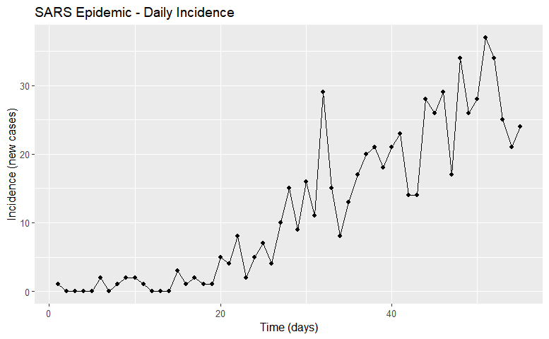

```r
# Plot raw incidence data
ggplot(data = sars, aes(x = Time, y = Incidence)) +
  geom_point() +
  geom_line() +
  xlab("Time (days)") +
  ylab("Incidence (new cases)") +
  ggtitle("SARS Epidemic - Daily Incidence")
```

3. **By visual inspection of the plotted graph, when would you think the exponential growth phase ends?**

Log-transforming the y-values makes it easier to identify the exponential phase, as an exponential curve $e^{rt}$ becomes linear when plotted on a logarithmic scale (since $\log(e^{rt}) = rt$).

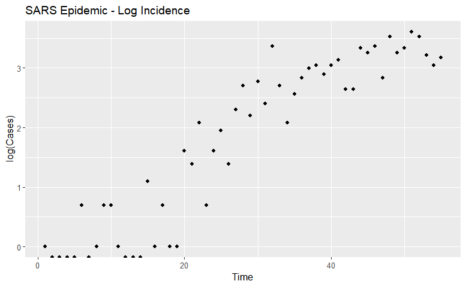

```r
# Plot log-transformed incidence
sars.plot <- ggplot() +
  geom_point(data = sars, aes(x = Time, y = log(Incidence))) +
  xlab("Time") +
  ylab("log(Cases)") +
  ggtitle("SARS Epidemic - Log Incidence")

sars.plot
```

4. **By visual inspection of the log plot, when does the exponential growth phase end?**

```r
# Set the end of exponential phase (change this value based on your inspection)
end.exp.phase <- 30  # Default value - adjust as needed
cat("End of exponential phase set to day:", end.exp.phase, "\n")
```

```
End of exponential phase set to day: 30
```

## Maximum Likelihood Estimation

We model the incidence as $i(t) = i(0)e^{rt}$ and assume the observed incidences follow a Poisson distribution with mean $i(t)$. The log-likelihood function is:

$$\text{log-likelihood} = \sum
\log\left(\frac{e^{-i(t)} i(t)^{c(t)}}{c(t)!}\right)$$

```r
# Log-likelihood function for the selected data
# We use suppressWarnings to avoid warnings when the algorithm tries values outside possible range
# The function assumes:
# 1. Poisson distributed counts around an expected value
# 2. An exponential growth of the number of cases

dLL <- function(y0, r, log = TRUE) {
  -sum(suppressWarnings(log(dpois(x = sars$Incidence[sars$Time <= end.exp.phase],
                                  lambda = y0 * exp(r * sars$Time[sars$Time <= end.exp.phase]),
                                  log = FALSE))))
}

# Fit the model using maximum likelihood
fit <- mle2(minuslogl = dLL, start = list(y0 = 1, r = 0.1))
fit
```

```
Call:
mle2(minuslogl = dLL, start = list(y0 = 1, r = 0.1))

Coefficients:
       y0         r
0.1904660 0.1426561

Log-likelihood: -50.17
```

5. **What is the value of the log-likelihood? What is the estimated $r$?**

We can also use a generalized linear model with Poisson family:

```r
# GLM approach - the formula is ln(y) ~ ln(y0) + r*t
fit.glm <- glm(formula = Incidence ~ Time,
               data = sars[sars$Time <= end.exp.phase, ],
               family = "poisson")

# Extract coefficients
# In the GLM: ln(y) ~ ln(y0) + r*t, so:
# coef[1] = ln(y0), coef[2] = r
y0.est <- exp(coef(fit.glm)[1])
r.est <- coef(fit.glm)[2]

cat("GLM Estimates:\n")
```

```
GLM Estimates:
```

```r
cat("y0 (initial incidence):", y0.est, "\n")
```

```
y0 (initial incidence): 0.1901026
```

```r
cat("r (exponential growth rate):", r.est, "\n")
```

```
r (exponential growth rate): 0.1427241
```

## Model fitting visualization

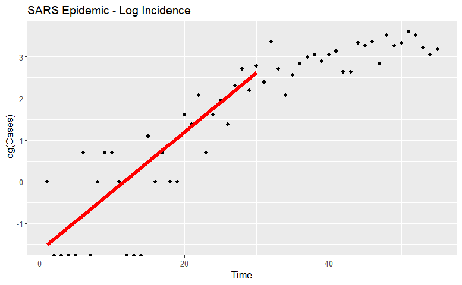

```r
# Add fitted model for exponential phase
sars.plot +
  geom_line(data = data.frame(Time = seq(1, end.exp.phase, 1),
                               Incidence = sapply(X = seq(1, end.exp.phase, 1),
                                                  function(t){log(y0.est * exp(r.est * t))})),
            aes(Time, Incidence),
            linetype = 1, linewidth = 2, colour = "red")
```

Now add extrapolation after the exponential phase:

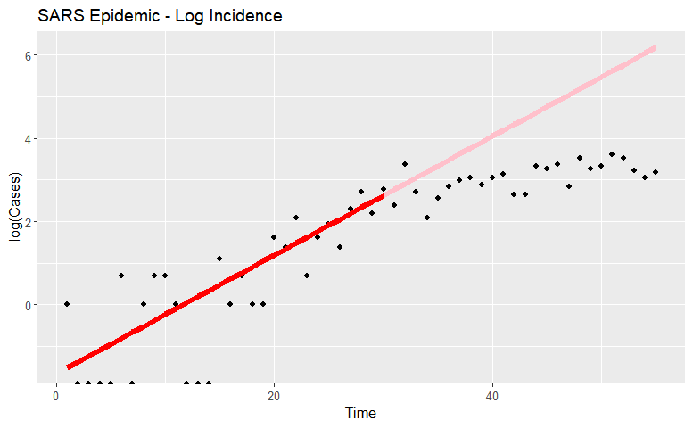

```r
sars.plot +
  geom_line(data = data.frame(Time = seq(1, end.exp.phase, 1),
                               Incidence = sapply(X = seq(1, end.exp.phase, 1),
                                                  function(t){log(y0.est * exp(r.est * t))})),
            aes(Time, Incidence),
            linetype = 1, linewidth = 2, colour = "red") +
  geom_line(data = data.frame(Time = seq(end.exp.phase, 55, 1),
                               Incidence = sapply(X = seq(end.exp.phase, 55, 1),
                                                  function(t){log(y0.est * exp(r.est * t))})),
            aes(Time, Incidence),
            linetype = 1, linewidth = 2, colour = "pink")
```

6. **Was the selected end of the exponential phase chosen correctly?**

## Estimating R₀

The mean generation time $T_g$ for SARS is estimated to be in the range of 10-16 days. Using the relationship $R_0 = 1 + r T_g$:

```r
# Literature values for generation time
Tg <- 16  # Can be adjusted between 10-16

# Calculate R0
R0_estimate <- 1 + r.est * Tg

cat("With Tg =", Tg, "days:\n")
```

```
With Tg = 16 days:
```

```r
cat("R0 estimate:", R0_estimate, "\n\n")
```

```
R0 estimate: 3.283586
```

```r
# Range for different Tg values
Tg_range <- seq(10, 16, by = 1)
R0_range <- 1 + r.est * Tg_range

cat("R0 range for Tg = 10 to 16 days:\n")
```

```
R0 range for Tg = 10 to 16 days:
```

```r
for(i in 1:length(Tg_range)) {
  cat("Tg =", Tg_range[i], "days: R0 =", R0_range[i], "\n")
}
```

```
Tg = 10 days: R0 = 2.427241
Tg = 11 days: R0 = 2.569966
Tg = 12 days: R0 = 2.71269
Tg = 13 days: R0 = 2.855414
Tg = 14 days: R0 = 2.998138
Tg = 15 days: R0 = 3.140862
Tg = 16 days: R0 = 3.283586
```

7. **What is the range of R₀ values for the possible generation times (10-16 days)?**

# 2. Estimation of R₀ from the final size of an epidemic

## Theory

The **final size** of an epidemic is the fraction of the population that has experienced infection by the end of the epidemic. The final size is directly related to the transmission potential and R₀.

In a homogeneously mixing population, the **final size equation** is:

$$1 - z(\infty) = \exp(-z(\infty)
R_0)$$

where $z(\infty)$ is the final size (proportion of population infected).

From this equation, we can derive the estimator for R₀:

$$R_0 = \frac{-\log(1 -
z(\infty))}{z(\infty)}$$

This estimator is general for homogeneously mixing populations and is **independent of the distribution of the generation time**, unlike the estimation from exponential growth.

## The dataset

This dataset is derived from an epidemic of influenza A virus (H3N8) among racehorses in Japan, 1971. It contains the population size of five race courses and the number of horses that got infected during the outbreak.

```r
# Load racing horses data
race <- read.csv(paste0(data_path,"RacingHorses.csv"), header = TRUE, sep = ",")

# View the data
race
```

| Race.course | Population | Infected |
| --- | --- | --- |
| Niigata | 640 | 580 |
| Haruki | 764 | 626 |
| Fukuyama | 684 | 667 |
| Kawasaki | 670 | 613 |
| Uwrawa | 650 | 505 |

### Questions

1. **What was the final size of the outbreak in Niigata?**

```r
# Calculate final size for each race course
race$FS <- race$Infected / race$Population

# Final size in Niigata
niigata_fs <- race$FS[race$Race.course == "Niigata"]
cat("Final size in Niigata:", niigata_fs, "\n")
```

```
Final size in Niigata: 0.90625
```

```r
# Show all final sizes
race[, c("Race.course", "Infected", "Population", "FS")]
```

| Race.course | Infected | Population | FS |
| --- | --- | --- | --- |
| Niigata | 580 | 640 | 0.9062500 |
| Haruki | 626 | 764 | 0.8193717 |
| Fukuyama | 667 | 684 | 0.9751462 |
| Kawasaki | 613 | 670 | 0.9149254 |
| Uwrawa | 505 | 650 | 0.7769231 |

## Visualizing final sizes

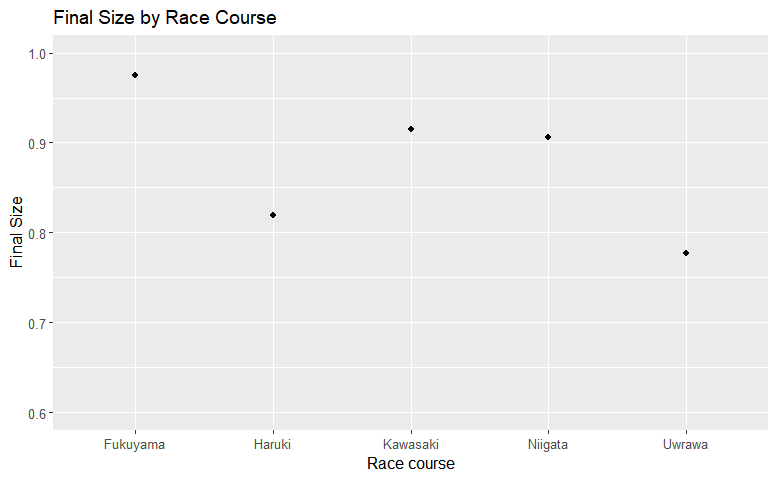

```r
# Basic plot of final sizes
ggplot() +
  geom_point(aes(y = (race$Infected/race$Population), x = factor(race$Race.course))) +
  xlab("Race course") +
  ylab("Final Size") +
  ylim(c(0.6, 1)) +
  ggtitle("Final Size by Race Course")
```

## Confidence intervals

We calculate confidence intervals using the normal approximation to the binomial distribution. The standard error for a proportion is:

$$SE =
\sqrt{\frac{p(1-p)}{n}}$$

2. **How do you calculate the standard error for a proportion?**

```r
# Calculate standard deviation of the final size
race$sdFS <- sqrt(race$FS * (1 - race$FS) / race$Population)

# Show standard errors
race[, c("Race.course", "FS", "sdFS")]
```

| Race.course | FS | sdFS |
| --- | --- | --- |
| Niigata | 0.9062500 | 0.011521782 |
| Haruki | 0.8193717 | 0.013918315 |
| Fukuyama | 0.9751462 | 0.005952552 |
| Kawasaki | 0.9149254 | 0.010778429 |
| Uwrawa | 0.7769231 | 0.016329002 |

Now plot the final sizes with 95% confidence intervals:

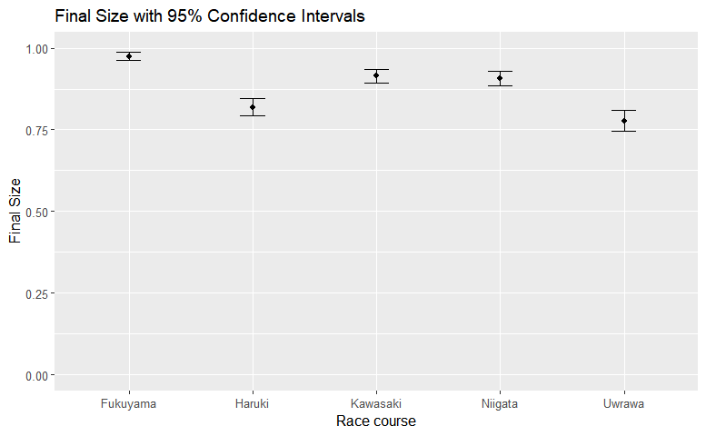

```r
# Plot final sizes with confidence intervals
ggplot(race) +
  geom_point(aes(x = Race.course, y = FS)) +
  geom_errorbar(aes(x = Race.course, ymin = FS - 1.96 * sdFS, ymax = FS + 1.96 * sdFS),
                width = 0.2) +
  xlab("Race course") +
  ylab("Final Size") +
  ylim(c(0, 1)) +
  ggtitle("Final Size with 95% Confidence Intervals")
```

## Estimating R₀ from final size

```r
# Calculate R0 and confidence intervals
race$R0 <- -log(1 - race$FS) / race$FS

# Confidence intervals for R0
# Upper limit: corresponds to smallest fraction susceptibles
race$R0.ul <- -log(1 - race$FS - 1.96 * race$sdFS) / (race$FS - 1.96 * race$sdFS)

# Lower limit: corresponds to largest fraction susceptibles
race$R0.ll <- -log(1 - race$FS + 1.96 * race$sdFS) / (race$FS + 1.96 * race$sdFS)

# Show results
race[, c("Race.course", "FS", "R0", "R0.ll", "R0.ul")]
```

| Race.course | FS | R0 | R0.ll | R0.ul |
| --- | --- | --- | --- | --- |
| Niigata | 0.9062500 | 2.611998 | 2.316134 | 2.990630 |
| Haruki | 0.8193717 | 2.088569 | 1.855142 | 2.367204 |
| Fukuyama | 0.9751462 | 3.788913 | 3.354103 | 4.492613 |
| Kawasaki | 0.9149254 | 2.693363 | 2.395626 | 3.076384 |
| Uwrawa | 0.7769231 | 1.931000 | 1.688866 | 2.221861 |

3. **Which race course had the highest R₀? Which race courses have significantly different R₀ values, based on the confidence intervals?**

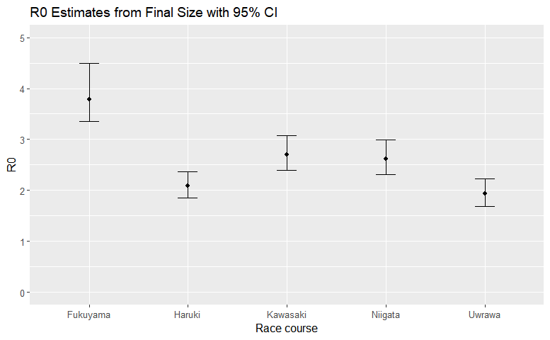

```r
# Plot R0 estimates
ggplot(race) +
  geom_point(aes(x = Race.course, y = R0)) +
  geom_errorbar(aes(x = Race.course, ymin = R0.ll, ymax = R0.ul),
                width = 0.2) +
  xlab("Race course") +
  ylab("R0") +
  ylim(c(0, 5)) +
  ggtitle("R0 Estimates from Final Size with 95% CI")
```

# 3. Estimation of R₀ from the endemic steady state

## Theory

When an infection is **endemic** in a population, the proportions of susceptible, infected, and recovered animals remain approximately constant over time.

### Basic SIR model with demography

In the basic SIR model with birth and mortality:

$$\begin{array}{l}
\frac{dx}{dt} = \mu - \beta xy - \mu x
\frac{dy}{dt} = \beta xy - \gamma y - \mu y
\frac{dz}{dt} = \gamma y - \mu z
\end{array}$$

The steady state proportion of immunes is:

$$z^* = \frac{\gamma}{\mu + \gamma}
\left(1 - \frac{1}{R_0}\right)$$

If we observe $z^*$ (the seroprevalence), we can estimate R₀ as:

$$R_0 = \frac{1}{1 - z^* \frac{\mu +
\gamma}{\gamma}}$$

For many infectious diseases with life-long immunity, $\gamma \gg \mu$, so $(\mu + \gamma)/\gamma \approx 1$ and $R_0 \approx 1/(1 - z^*)$.

### SIS-like model for Salmonella Dublin

For Salmonella Dublin in dairy cows, we use a more complex model because cows lose immunity relatively quickly. We include a latent period and neglect mortality (since infection and loss of immunity occur much faster than birth and death):

$$\begin{array}{l}
\frac{dx}{dt} = \eta z - \beta x y \\
\frac{dw}{dt} = \beta x y - \sigma w \\
\frac{dy}{dt} = \sigma w - \gamma y \\
\frac{dz}{dt} = \gamma y - \eta z \\
\end{array}$$

Where:

- $x$ = susceptible
- $w$ = latent (exposed but not yet infectious)
- $y$ = infectious
- $z$ = immune (seropositive)

The steady state proportion of immune individuals is:

$$z^* = \left(1 - \frac{1}{R_0}\right)
\frac{\gamma \sigma}{\gamma \sigma + \eta \sigma + \eta \gamma} =
\left(1 - \frac{1}{R_0}\right) \frac{D_S}{D_S + L + D}$$

Where:

- $R_0 = \beta / \gamma$
- $D_S$ = mean duration of seropositivity = $1/\eta$
- $L$ = mean latent period = $1/\sigma$
- $D$ = mean infectious period = $1/\gamma$
1. **How would you express $D_S$, $L$, and $D$ in terms of the model parameters $\beta$, $\sigma$, $\gamma$, and $\eta$?**

From the steady state seroprevalence, we can derive:

$$R_0 = \frac{1}{1 - z^* \left(1 + \frac{L
+ D}{D_S}\right)}$$

## The dataset

This dataset contains seroprevalence data of Salmonella Dublin from two Dutch dairy herds (Van Schaik et al. 2007; Vet Res 38, pp 861-9). For each sampling day, the number of cows and the number of seropositive cows are recorded.

```r
# Load Salmonella data
salmo <- read.csv(paste0(data_path,"Salmonella.csv"), header = TRUE, sep = ",")

# View first few rows
head(salmo)
```

|  | Herd | Day | Herd.size | Seropositive |
| --- | --- | --- | --- | --- |
| 1 | 1 | 0 | 109 | 31 |
| 2 | 1 | 13 | 107 | 51 |
| 3 | 1 | 28 | 107 | 65 |
| 4 | 1 | 56 | 110 | 72 |
| 5 | 1 | 84 | 110 | 71 |
| 6 | 1 | 181 | 116 | 72 |

### Questions

2. **What are the final seroprevalences in both herds, and what were the time intervals between the first sample and these observations?**

```r
# Summary of the data
summary(salmo)
```

```
      Herd            Day          Herd.size      Seropositive
 Min.   :1.000   Min.   :  0.0   Min.   : 94.0   Min.   :13
 1st Qu.:1.000   1st Qu.: 28.0   1st Qu.: 99.0   1st Qu.:38
 Median :2.000   Median : 83.0   Median :100.0   Median :41
 Mean   :1.647   Mean   :148.4   Mean   :102.4   Mean   :45
 3rd Qu.:2.000   3rd Qu.:181.0   3rd Qu.:107.0   3rd Qu.:51
 Max.   :2.000   Max.   :587.0   Max.   :116.0   Max.   :72
```

```r
# Final observations for each herd
final_herd1 <- salmo[salmo$Herd == 1 & salmo$Day == max(salmo$Day[salmo$Herd == 1]), ]
final_herd2 <- salmo[salmo$Herd == 2 & salmo$Day == max(salmo$Day[salmo$Herd == 2]), ]

cat("Herd 1 - Final observation:\n")
```

```
Herd 1 - Final observation:
```

```r
print(final_herd1)
```

|  | Herd | Day | Herd.size | Seropositive |
| --- | --- | --- | --- | --- |
| 6 | 1 | 181 | 116 | 72 |

```r
cat("\nHerd 2 - Final observation:\n")
```

```
Herd 2 - Final observation:
```

```r
print(final_herd2)
```

|  | Herd | Day | Herd.size | Seropositive |
| --- | --- | --- | --- | --- |
| 17 | 2 | 587 | 99 | 39 |

## Visualizing seroprevalence over time

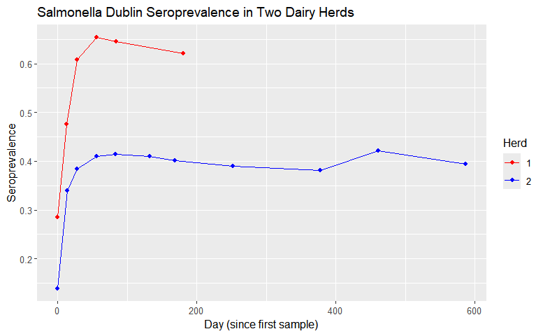

```r
# Plot seroprevalence over time for both herds
salmo.plot <- ggplot() +
  geom_path(data = salmo, aes(x = Day, y = Seropositive/Herd.size, colour = factor(Herd))) +
  geom_point(data = salmo, aes(x = Day, y = Seropositive/Herd.size, colour = factor(Herd))) +
  scale_colour_manual(name = "Herd", values = c("red", "blue")) +
  xlab("Day (since first sample)") +
  ylab("Seroprevalence") +
  ggtitle("Salmonella Dublin Seroprevalence in Two Dairy Herds")

salmo.plot
```

3. **By visual inspection, when does the endemic steady state start for the two herds?**

## Estimating endemic equilibrium

```r
# Set the beginning of the endemic equilibrium for each herd
# Adjust these values based on your visual inspection
start.end.eq.herd1 <- 13
start.end.eq.herd2 <- 50

cat("Endemic equilibrium starts at:\n")
```

```
Endemic equilibrium starts at:
```

```r
cat("Herd 1: Day", start.end.eq.herd1, "\n")
```

```
Herd 1: Day 13
```

```r
cat("Herd 2: Day", start.end.eq.herd2, "\n")
```

```
Herd 2: Day 50
```

```r
# Estimate the endemic equilibrium (mean seroprevalence during steady state)
end.eq.herd1 <- mean(salmo$Seropositive[salmo$Herd == 1 & salmo$Day >= start.end.eq.herd1] /
                    salmo$Herd.size[salmo$Herd == 1 & salmo$Day >= start.end.eq.herd1])

end.eq.herd2 <- mean(salmo$Seropositive[salmo$Herd == 2 & salmo$Day >= start.end.eq.herd2] /
                    salmo$Herd.size[salmo$Herd == 2 & salmo$Day >= start.end.eq.herd2])

cat("Endemic equilibrium seroprevalence:\n")
```

```
Endemic equilibrium seroprevalence:
```

```r
cat("Herd 1:", end.eq.herd1, "\n")
```

```
Herd 1: 0.6009604
```

```r
cat("Herd 2:", end.eq.herd2, "\n")
```

```
Herd 2: 0.4028172
```

4. **What were the seroprevalences in the endemic steady states for the two herds?**

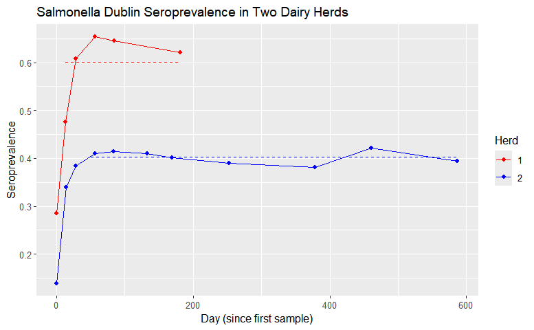

```r
salmo.plot +
  geom_line(aes(y = c(end.eq.herd1, end.eq.herd1),
                x = c(start.end.eq.herd1, max(salmo$Day[salmo$Herd == 1]) + 1)),
            linetype = 2, colour = "red") +
  geom_line(aes(y = c(end.eq.herd2, end.eq.herd2),
                x = c(start.end.eq.herd2, max(salmo$Day[salmo$Herd == 2]) + 1)),
            linetype = 2, colour = "blue")
```

5. **Do you still agree on the starting moment of the steady state?**

## Estimating R₀ from endemic equilibrium

From literature:

- Latent period (L) ≈ 2 days
- Infectious period (D) ≈ 10 days
- Duration of seropositivity (D_S) ≈ 90 days (3 months)

```r
# Literature values
lat <- 2    # Latent period in days
inf <- 10   # Infectious period in days
imm <- 90   # Duration of seropositivity in days

# Calculate R0 for both herds
R0.end.herd1 <- 1 / (1 - (1 + (lat + inf)/imm) * end.eq.herd1)
R0.end.herd2 <- 1 / (1 - (1 + (lat + inf)/imm) * end.eq.herd2)

cat("R0 estimates from endemic equilibrium:\n")
```

```
R0 estimates from endemic equilibrium:
```

```r
cat("Herd 1: R0 =", R0.end.herd1, "\n")
```

```
Herd 1: R0 = 3.135665
```

```r
cat("Herd 2: R0 =", R0.end.herd2, "\n")
```

```
Herd 2: R0 = 1.840015
```

6. **What was R₀ in the two herds?**

## Sensitivity analysis (Bonus)

7. **How sensitive is the estimate of R₀ to the values found in literature of the latent period, the infectious period, and the time during which cows are seropositive?**

```r
# Create a sensitivity analysis function
sensitivity_r0 <- function(lat_range, inf_range, imm_range, seroprev) {
  results <- expand.grid(
    Latent = lat_range,
    Infectious = inf_range,
    Immunity = imm_range
  )

  results$R0 <- 1 / (1 - (1 + (results$Latent + results$Infectious) / results$Immunity) * seroprev)

  return(results)
}

# Test for Herd 1
lat_range <- seq(1, 3, by = 0.5)  # Latent period: 1-3 days
inf_range <- seq(8, 12, by = 1)   # Infectious period: 8-12 days
imm_range <- seq(80, 100, by = 5) # Seropositivity: 80-100 days

sens_herd1 <- sensitivity_r0(lat_range, inf_range, imm_range, end.eq.herd1)
sens_herd2 <- sensitivity_r0(lat_range, inf_range, imm_range, end.eq.herd2)

# Summary of sensitivity for Herd 1
cat("Sensitivity Analysis for Herd 1:\n")
```

```
Sensitivity Analysis for Herd 1:
```

```r
cat("Min R0:", min(sens_herd1$R0), "\n")
```

```
Min R0: 2.898944
```

```r
cat("Max R0:", max(sens_herd1$R0), "\n")
```

```
Max R0: 3.492113
```

```r
cat("Mean R0:", mean(sens_herd1$R0), "\n\n")
```

```
Mean R0: 3.145421
```

```r
cat("Sensitivity Analysis for Herd 2:\n")
```

```
Sensitivity Analysis for Herd 2:
```

```r
cat("Min R0:", min(sens_herd2$R0), "\n")
```

```
Min R0: 1.782756
```

```r
cat("Max R0:", max(sens_herd2$R0), "\n")
```

```
Max R0: 1.916977
```

```r
cat("Mean R0:", mean(sens_herd2$R0), "\n")
```

```
Mean R0: 1.841584
```

# Summary and Conclusions

This practical has demonstrated three complementary methods for estimating R₀ from field data:

1. **Exponential growth phase**: Fast and simple when early epidemic data is available, but requires knowledge of generation time and assumes exponential growth.
2. **Final size**: Useful for completed epidemics, independent of generation time distribution, but requires final size data and assumes homogeneous mixing.
3. **Endemic equilibrium**: Appropriate for persistent infections, but requires seroprevalence data at steady state and knowledge of disease natural history parameters.

Each method has its strengths and limitations, and the choice depends on the available data and the epidemiological context.

## References

- Van Schaik, G., et al. (2007). Salmonella Dublin in dairy cattle: a longitudinal study in two herds. Veterinary Research, 38, 861-869.